# act_report

```python
import pandas as pd
import numpy as np
import matplotlib.pyplot as plt
%matplotlib inline
import seaborn as sns
```

```python
all_details = pd.read_csv('Output/twitter_archive_master.csv')
print (all_details.shape)
all_details.head()
```

```
(1994, 23)
```

|  | tweet_id | timestamp | source | text | expanded_urls | rating_numerator | rating_denominator | name | jpg_url | p1 | ... | p2_conf | p2_dog | p3 | p3_conf | p3_dog | favorite_count | retweet_count | dog_stage | breed | confidence |
| --- | --- | --- | --- | --- | --- | --- | --- | --- | --- | --- | --- | --- | --- | --- | --- | --- | --- | --- | --- | --- | --- |
| 0 | 892420643555336193 | 2017-08-01 16:23:56 | Twitter for iPhone | This is Phineas. He's a mystical boy. Only eve... | https://twitter.com/dog_rates/status/892420643... | 13.0 | 10 | Phineas | https://pbs.twimg.com/media/DGKD1-bXoAAIAUK.jpg | orange | ... | 0.085851 | False | banana | 0.076110 | False | 39467 | 8853 | NaN | NaN | NaN |
| 1 | 892177421306343426 | 2017-08-01 00:17:27 | Twitter for iPhone | This is Tilly. She's just checking pup on you.... | https://twitter.com/dog_rates/status/892177421... | 13.0 | 10 | Tilly | https://pbs.twimg.com/media/DGGmoV4XsAAUL6n.jpg | chihuahua | ... | 0.090647 | True | papillon | 0.068957 | True | 33819 | 6514 | NaN | chihuahua | 0.323581 |
| 2 | 891815181378084864 | 2017-07-31 00:18:03 | Twitter for iPhone | This is Archie. He is a rare Norwegian Pouncin... | https://twitter.com/dog_rates/status/891815181... | 12.0 | 10 | Archie | https://pbs.twimg.com/media/DGBdLU1WsAANxJ9.jpg | chihuahua | ... | 0.078253 | True | kelpie | 0.031379 | True | 25461 | 4328 | NaN | chihuahua | 0.716012 |
| 3 | 891689557279858688 | 2017-07-30 15:58:51 | Twitter for iPhone | This is Darla. She commenced a snooze mid meal... | https://twitter.com/dog_rates/status/891689557... | 13.0 | 10 | Darla | https://pbs.twimg.com/media/DF_q7IAWsAEuuN8.jpg | paper towel | ... | 0.168086 | True | spatula | 0.040836 | False | 42908 | 8964 | NaN | labrador retriever | 0.168086 |
| 4 | 891327558926688256 | 2017-07-29 16:00:24 | Twitter for iPhone | This is Franklin. He would like you to stop ca... | https://twitter.com/dog_rates/status/891327558... | 12.0 | 10 | Franklin | https://pbs.twimg.com/media/DF6hr6BUMAAzZgT.jpg | basset | ... | 0.225770 | True | german short-haired pointer | 0.175219 | True | 41048 | 9774 | NaN | basset | 0.555712 |

5 rows × 23 columns

# Analyzing and Visualizing

This section provides an analysis of the data set, and corresponding visualizations to draw valuable conclusions.

1. Scatterplot to see the correlation between favorite_count and retweet_count
2. Visualizing Rating Numerators Distribution
3. Boxplot between retweet and dog stages
4. Visualizing the most popular dog category by pie chart
5. Visualizing the frequency of the tweet sources by histogram chart
6. Visualizing the most popular dog name by histogram chart
7. Visualizing Distribution of Retweet Count vs Favorite Count

```python
all_details.head(1)
```

|  | tweet_id | timestamp | source | text | expanded_urls | rating_numerator | rating_denominator | name | jpg_url | p1 | ... | p2_conf | p2_dog | p3 | p3_conf | p3_dog | favorite_count | retweet_count | dog_stage | breed | confidence |
| --- | --- | --- | --- | --- | --- | --- | --- | --- | --- | --- | --- | --- | --- | --- | --- | --- | --- | --- | --- | --- | --- |
| 0 | 892420643555336193 | 2017-08-01 16:23:56 | Twitter for iPhone | This is Phineas. He's a mystical boy. Only eve... | https://twitter.com/dog_rates/status/892420643... | 13.0 | 10 | Phineas | https://pbs.twimg.com/media/DGKD1-bXoAAIAUK.jpg | orange | ... | 0.085851 | False | banana | 0.07611 | False | 39467 | 8853 | NaN | NaN | NaN |

1 rows × 23 columns

## 1- Scatterplot to see the correlation between favorite_count and retweet_count

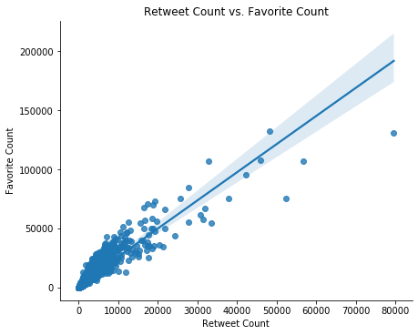

```python
sns.lmplot(x="retweet_count",
           y="favorite_count",
           data=all_details,
           size = 5,
           aspect=1.3);

plt.title('Retweet Count vs. Favorite Count');
plt.xlabel('Retweet Count');
plt.ylabel('Favorite Count');
```

There is a positive relationship between the favorite counts and retweet counts since as the retweet counts increase the favorite counts as well.

## 2- Visualizing Rating Numerators Distribution

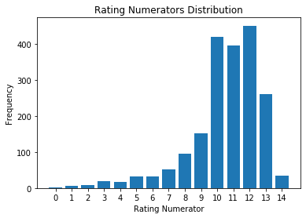

```python
ratings = all_details[(all_details.rating_numerator <= 15) & (all_details.rating_numerator.apply(float.is_integer))]
rating_counts = ratings.groupby(['rating_numerator']).count()['tweet_id']

plt.bar(np.arange(15), rating_counts)
plt.xticks(np.arange(15))
plt.xlabel('Rating Numerator')
plt.ylabel('Frequency')
plt.title('Rating Numerators Distribution');
```

As we can see from the above chart many dogs got rating from 10 to 12

## 3- Boxplot between retweet and dog stages

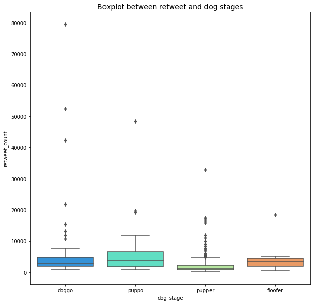

```python
plt.figure(figsize=(10,10))
g = sns.boxplot(x='dog_stage',y='retweet_count',data= all_details,palette='rainbow')
g.axes.set_title('Boxplot between retweet and dog stages', fontsize=14);
```

From the the shown chart, we can see that most dogs are in pupper category but highest retweeted in doggo stage

## 4- Visualizing the most popular dog category by pie chart

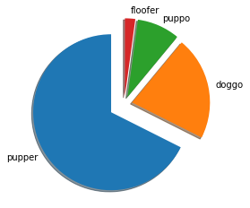

```python
dog_stage_count = list(all_details[all_details['dog_stage'] != 'None']['dog_stage'].value_counts())[0:4]
dog_stages = all_details[all_details['dog_stage'] != 'None']['dog_stage'].value_counts().index.tolist()[0:4]
explode = (0.2, 0.1, 0.1, 0.1)

fig1, ax1 = plt.subplots()
ax1.pie(dog_stage_count, explode = explode, labels = dog_stages, shadow = True, startangle = 90);
```

As well as in this chart, we can see that most dogs are in pupper category then in doggo category

## 5- Visualizing the frequency of the tweet sources by histogram

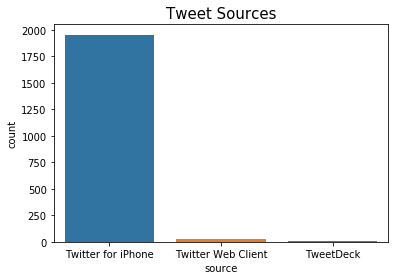

```python
sns.countplot(data=all_details, x='source')
plt.title('Tweet Sources', size=15)
```

Almost all the source of twwet is Twitter for iphone

## 6. Visualizing the most popular dog name by histogram chart

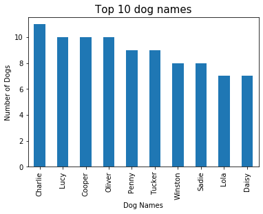

```python
all_details['name'].value_counts()[1:11].sort_values(ascending=False).plot(kind = 'bar')
plt.ylabel('Number of Dogs')
plt.title('Top 10 dog names', size=15)
plt.xlabel('Dog Names');
```

## 7- Visualizing Distribution of Retweet Count VS Favorite Count

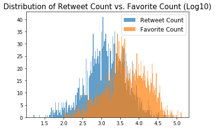

```python
retweet_log10 = all_details['retweet_count'].apply(lambda x: np.log10(x))
favorite_log10 = all_details['favorite_count'].apply(lambda x: np.log10(x))
plt.hist(retweet_log10, alpha=0.7, bins=200, label='Retweet Count')
plt.hist(favorite_log10, alpha=0.7, bins=200, label='Favorite Count')
plt.title('Distribution of Retweet Count vs. Favorite Count (Log10)', size=15)
plt.legend(loc='upper right', fontsize=12);
```

From the above chart, we can see that users favor the tweets more than they retweet them.